# Airplane Crashes since 1908

Brian Wang

8/2/2017

I obtained this data set via Kaggle at https://www.kaggle.com/saurograndi/airplane-crashes-since-1908. I’m going to explore it with some light visualizations in order to get an understanding of which airlines had the most crashes / were the least safe from 1908-2009, which is the latest year in the dataset.

```r
library(tidyverse)
library(readr)
library(DT)
library(data.table)
```

# Load data

```r
airplanes <- read_csv("/Users/brianwang/Desktop/r/data-projects/airplane-crashes/airplane_crashes_1908.csv", col_types = cols(
  `Date` = col_date(format="%m/%d/%Y"),
  Time = col_character(),
  Location = col_character(),
  Operator = col_character(),
  `Flight #` = col_character(),
  Route = col_character(),
  Type = col_character(),
  Registration = col_character(),
  `cn/In` = col_character(),
  Aboard = col_integer(),
  Fatalities = col_integer(),
  Ground = col_integer()
))
```

A summary of the columns in this dataset:

- `Date` - date of the crash
- `Time` - time of the crash
- `Location` - location of the crash
- `Operator` - airline operator
- `Flight #` - flight number
- `Route` - aircraft route
- `Type` - type of aircraft
- `Registration` - aircraft registration identifier - see https://en.wikipedia.org/wiki/Aircraft_registration
- `cn/In` - aircraft construction number?
- `Aboard - number of passengers aboard
- `Fatalities - number of passenger fatalities
- `Ground` - So I’m actually not sure what this variable is.
- `Summary` - summary description of incident

I noticed when I was importing the data that there were a few observations that had extra characters in the Time column, so I’m going to clean this data and then convert the Time column to a time variable.

```r
airplanes$Time[3537] <- '09:43'
airplanes$Time[3268] <- '14:20'
airplanes$Time <- gsub("['\\.]",":",airplanes$Time)
airplanes$Time <- parse_time(gsub("c[:]*","",airplanes$Time),format="%R")
```

# Total crashes, passengers aboard, fatalities and survivors per year

```r
counts <- airplanes %>%
  group_by(Year=year(Date)) %>%
  summarise(Count = n())
```

```r
p1 <- counts %>%
  ggplot(aes(x=Year, y=Count)) +
  geom_col(fill="#0b9f93") +
  geom_col(data = subset(counts,Count==max(Count)), fill="yellow", color="black") +
  geom_text(data = subset(counts,Count==max(Count)), aes(label=Count), vjust=-0.5, size = 3) +
  ggtitle("Crashes per year, 1908 - 2009")
```

```r
aboard <- airplanes %>%
  group_by(Year=year(Date)) %>%
  summarise(Count = sum(Aboard, na.rm=TRUE))
```

```r
p2 <- aboard %>%
  ggplot(aes(x=Year, y=Count)) +
  geom_col(fill="#8b3f83") +
  geom_col(data = subset(aboard,Count==max(Count)), fill="yellow", color="black") +
  geom_text(data = subset(aboard,Count==max(Count)), aes(label=Count), vjust=-0.5, size = 3) +
  ggtitle("Aboard passengers per year, 1908 - 2009")
```

```r
fatalities <- airplanes %>%
  group_by(Year=year(Date)) %>%
  summarise(Count = sum(Fatalities, na.rm=TRUE))
```

```r
p3 <- fatalities %>%
  ggplot(aes(x=Year, y=Count)) +
  geom_col(fill="#0b9fc3") +
  geom_col(data = subset(fatalities,Count==max(Count)), fill="yellow", color="black") +
  geom_text(data = subset(fatalities,Count==max(Count)), aes(label=Count), vjust=-0.5, size = 3) +
  ggtitle("Fatalities per year, 1908 - 2009")
```

```r
airplanes$survivors <- airplanes$Aboard - airplanes$Fatalities
```

```r
survivors <- airplanes %>%
  group_by(Year = year(Date)) %>%
  summarise(Count = sum(survivors, na.rm=TRUE))
```

```r
p4 <- survivors %>%
  ggplot(aes(x=Year, y=Count)) +
  geom_col(fill="#0bbfc3") +
  geom_col(data = subset(survivors,Count==max(Count)), fill="yellow", color="black") +
  geom_text(data = subset(survivors,Count==max(Count)), aes(label=Count), vjust=-0.5, size = 3) +
  ggtitle("Survivors per year, 1908 - 2009")
```

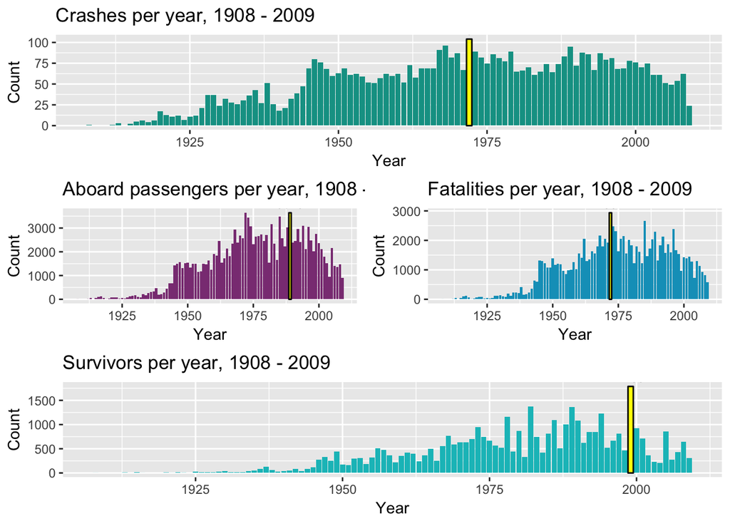

```r
multiplot(p1, p2, p3, p4, cols = 2, layout = matrix(c(1,2,4,1,3,4), nrow=3))
```

# What airline has had the most crashes since 1908?

```r
airplanes %>%
  group_by(Operator) %>%
  summarise("Count" = n()) %>%
  arrange(desc(Count)) %>% datatable()
```

|  | Operator | Count |
| --- | --- | --- |
| 1 | Aeroflot | 179 |
| 2 | Military - U.S. Air Force | 176 |
| 3 | Air France | 70 |
| 4 | Deutsche Lufthansa | 65 |
| 5 | Air Taxi | 44 |
| 6 | China National Aviation Corporation | 44 |
| 7 | United Air Lines | 44 |
| 8 | Military - U.S. Army Air Forces | 43 |
| 9 | Pan American World Airways | 41 |
| 10 | American Airlines | 36 |

[output cut: 2467 more lines]

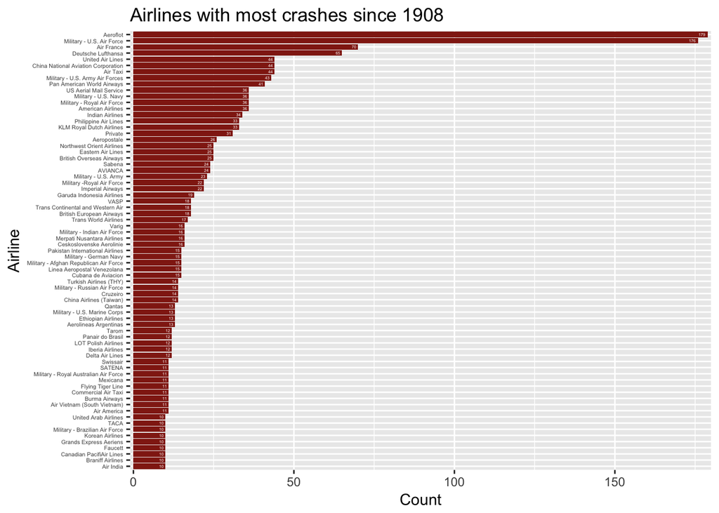

```r
airplanes %>%
  group_by(Operator) %>%
  summarise(Count = n()) %>% arrange(desc(Count)) %>%
  filter(Count >= 10) %>% na.omit() %>%
  ggplot(aes(x=reorder(Operator,Count), y=Count)) +
  geom_col(fill="#922415") +
  geom_text(aes(label=Count), size = 1, hjust = 1.4, color = "#FFFFFF") +
  ggtitle("Airlines with most crashes since 1908") +
  labs(x="Airline", y="Count") +
  theme(axis.text.y = element_text(size = 4)) +
  scale_y_continuous(expand=c(0,1)) +
  coord_flip()
```

```r
topten <- (airplanes %>%
  group_by(Operator) %>%
  summarise("Count" = n()) %>%
  arrange(desc(Count)))$Operator[1:10]
```

```r
toptenbyyear <- airplanes %>%
  filter(Operator %in% topten) %>%
  group_by(Year = year(Date), Operator) %>%
  summarise(Count = n()) %>% arrange(desc(Count))
```

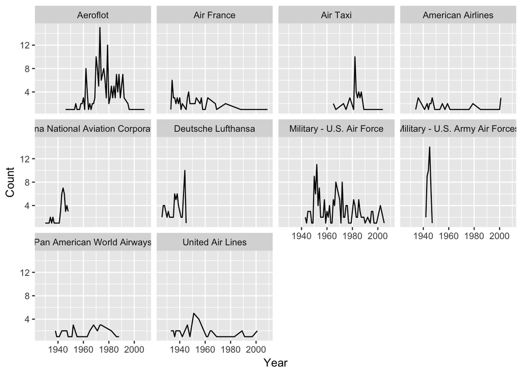

```r
toptenbyyear %>%
  ggplot(aes(x=Year, y=Count)) + geom_line() + facet_wrap(~Operator)
```

There’s a few things that we can note from this chart:

- We observe that there are a quite a few airlines that have no crashes for a significant number of years in the period 1908-2009.
- The U.S. Army Air Forces (1947) and Deutsche Lufthansa (1945) both ceased to exist shortly after World War II - we can assume that most of these crashes are war-related.
- The China National Aviation Corporation ceased to exist after 1949, a side effect of the Chinese Civil War, when the managing director of CNAC defected to Communist-controlled China (while being pursued by KMT fighter planes!)
- Pan Am World Airways went bankrupt in 1991 and was sold to United Airlines, Delta Airlines, and Lufthansa, among other airlines.
- Air Taxi doesn’t seem to be a airline company - I wonder if this is just a combined label for air taxi operators.
- The remaining in the top ten are either currently operating airlines or military.
- Answering our previous question: it looks the 1970s were particularly rough for Aeroflot.

From this, we also note that it might not be accurate to judge the “safety” of an airline operator by the aggregate number of crashes it’s had. Instead, let’s try to compute a “crashes-per-year” metric, which is the total number of crashes normalized by the number of the years the airline was in operation. We also note that we don’t know if an airline had a crash both in its inaugural year and last year, so we will have to confirm the lifespan of the airline operator by outside sources. We can do this for the top ten airlines.

# Crashes / fatalities per year, normalized by airline operator lifetime

```r
toptenbyoperator <-
  airplanes %>%
  filter(Operator %in% topten) %>%
  group_by(Operator) %>%
  summarise(Count = n(), Fatalities = sum(Fatalities, na.rm=TRUE))
```

```r
toptenbyoperator$opyears <-
  c(2009-1923,
    2009-1933,
    NA, # Air Taxi
    2009-1936,
    1949-1929,
    1945-1926,
    2009-1947,
    1947-1941,
    1991-1927,
    2009-1926)
```

```r
toptenbyoperator %>%
  mutate("Crashes Per Year" = Count / opyears, "Fatalities Per Year" = Fatalities / opyears) %>%
  select(1:3, 5:6) %>% datatable() %>% formatRound(4:5, 2)
```

|  | Operator | Count | Fatalities | Crashes Per Year | Fatalities Per Year |
| --- | --- | --- | --- | --- | --- |
| 1 | Aeroflot | 179 | 7156 | 2.08139534883721 | 83.2093023255814 |
| 2 | Air France | 70 | 1734 | 0.921052631578947 | 22.8157894736842 |
| 3 | Air Taxi | 44 | 161 |  |  |
| 4 | American Airlines | 36 | 1421 | 0.493150684931507 | 19.4657534246575 |
| 5 | China National Aviation Corporation | 44 | 409 | 2.2 | 20.45 |
| 6 | Deutsche Lufthansa | 65 | 396 | 3.42105263157895 | 20.8421052631579 |
| 7 | Military - U.S. Air Force | 176 | 3717 | 2.83870967741935 | 59.9516129032258 |
| 8 | Military - U.S. Army Air Forces | 43 | 1070 | 7.16666666666667 | 178.333333333333 |
| 9 | Pan American World Airways | 41 | 1302 | 0.640625 | 20.34375 |
| 10 | United Air Lines | 44 | 1021 | 0.530120481927711 | 12.3012048192771 |